# Coursework 2 Part 1

**Replace CID in the file name with your CID**

# Outline

- Task 1: Dimensionality Reduction and Regression with Convolutional Neural Networks - CNNs
  - (1.1)
  - (1.2)
- Task 2: Graph-based learning
  - (2.1)
  - (2.2)

# Task 1: Dimensionality Reduction and Regression with Convolutional Neural Networks - CNNs (index)

## (1.1) (index)

```python
import numpy as np
import pandas as pd
import matplotlib.pyplot as plt
import torch
import torch.nn as nn
from torch.nn import Sequential, CrossEntropyLoss, Conv1d, MaxPool1d, Flatten, Linear, ReLU, Softmax, Parameter, Conv2d, MaxPool2d, ConvTranspose2d, Linear, MSELoss
from torch.utils.data import TensorDataset, DataLoader
import torch.optim as optim
```

```python
#Load the data
```

```python
df = pd.read_csv('gene_expression_transcriptomic_data (1).csv')
```

```python
data = df.to_numpy()
print("Dataset shape:", data.shape)
```

```
Dataset shape: (2641, 102)
```

```python
#Separate data as required, it is originally in numpy form.
X = data[:, :100]
y = data[:, 100]
y_treatment = data[:, 101]
```

```python
# Data preparation, separate them by given groups.
N_train, N_val, N_test = 1848, 264, 529

X_train, X_val, X_test = X[:N_train], X[N_train:N_train + N_val], X[N_train + N_val:]
y_train, y_val, y_test = y[:N_train], y[N_train:N_train + N_val], y[N_train + N_val:]

X_train = X_train.reshape(-1, 1, 10, 10)  # Reshape to this form, which same as the np.newline in lab. And convert the 100 features in 10*10 as required.
X_val = X_val.reshape(-1, 1, 10, 10)
X_test = X_test.reshape(-1, 1, 10, 10)

X_train_tensor = torch.tensor(X_train, dtype=torch.float32) #Convert into tensor form.
X_val_tensor = torch.tensor(X_val, dtype=torch.float32)
X_test_tensor = torch.tensor(X_test, dtype=torch.float32)
y_train_tensor = torch.tensor(y_train, dtype=torch.float32).unsqueeze(1)
y_val_tensor = torch.tensor(y_val, dtype=torch.float32).unsqueeze(1)
y_test_tensor = torch.tensor(y_test, dtype=torch.float32).unsqueeze(1)

batch_size = 32
train_loader = DataLoader(TensorDataset(X_train_tensor, y_train_tensor), batch_size=batch_size, shuffle=False) #Finally it get prepared as dataloader.
val_loader = DataLoader(TensorDataset(X_val_tensor, y_val_tensor), batch_size=batch_size, shuffle=False)
test_loader = DataLoader(TensorDataset(X_test_tensor, y_test_tensor), batch_size=batch_size, shuffle=False)
```

```python
#Get the model as required, here the input firstly has size: (batch_size, 1, 10, 10)
def getencoder():
    model = Sequential(
        Conv2d(in_channels=1, out_channels=8, kernel_size=(3,3), padding=1), #Initial in_channels is 1, stride is 1. The size turn to (10 + 2 - 3 + 1)
        ReLU(),
        MaxPool2d(kernel_size=(2,2), stride=2), #Size turn to ((10 - 2) / 2) + 1 = 5
        Conv2d(in_channels=8, out_channels=8, kernel_size=(3,3), padding = 1), #Size doesn't change as above
        ReLU(),
        ConvTranspose2d(in_channels=8, out_channels=1, kernel_size=(3,3), stride=2, padding=1, output_padding=1), #Size turn to (5-1) * stride - 2 + 3 + 1 = 10
        ReLU()
    )
    optimiser = torch.optim.Adam(model.parameters(), lr = 1e-3)
    return model, optimiser
```

```python
model_r, optimiser = getencoder()
```

```python
#Use the class from lab, I think I don't need to change anything so I just copy it.
class EarlyStopping:
    """
    EarlyStopping class.

    Attributes:
        max_patience (int): Amount of epochs with no improvement after which training is stopped.
        patience (int): Stores the number of epochs with no improvement.
        best_valid_loss (float): Stores the current value of the best (minimum) validation loss.
        early_stop (bool) True if training needs to be stopped due to the early stopping condition being met.

    Methods:
        step(val_loss):
            Checks current state after an epoch and updates best_loss, patience and early_stop accordingly.
    """

    def __init__(self, max_patience=5):
        self.max_patience = max_patience
        self.patience = 0
        self.best_valid_loss = float('inf') ## <-- SOLUTION
        self.early_stop = False

    def step(self, val_loss):
        if val_loss < self.best_valid_loss:  ## <-- SOLUTION
            self.best_valid_loss = val_loss  ## <-- SOLUTION
            self.patience = 0  ## <-- SOLUTION
        else:
            self.patience += 1
            if self.patience >= self.max_patience:
                self.early_stop = True
```

```python
#Define the mse function as required.
def mse_reconstruct_loss(x, x_hat):
    N = x.shape[0]
    diff = x.view(N, -1) - x_hat.view(N, -1)
    squared_error = torch.sum(diff ** 2, dim=1)
    loss = torch.mean(squared_error)
    return loss
```

```python
#Mostly copy from the lab, just need to change the estimation of loss.
def training_loop(train_loader, val_loader, model, optimiser, max_num_epochs=100, max_patience=5):

    history = {'training_loss': [], 'validation_loss': [], 'training_accuracy': [], 'validation_accuracy': []}
    early_stopping = EarlyStopping(max_patience=max_patience)

    for epoch in range(max_num_epochs):
        # Training Phase
        model.train()  # Ensure model is in training mode
        total_train_loss = 0.0
        for inputs, _ in train_loader:
            if inputs.ndim == 3:
                inputs = inputs.unsqueeze(1) #Make sure the dimension matches, has no exact usage.
            optimiser.zero_grad()  # Reset gradients
            outputs = model(inputs)  # Forward pass
            loss = mse_reconstruct_loss(inputs, outputs)  # Compute mse loss
            loss.backward()  # Backpropagate
            optimiser.step()  # Update parameters
            total_train_loss += loss.item() * inputs.size(0) #Multiple the batch, which takes the mean in mse_loss, so we need to multiple this again.
        avg_train_loss = total_train_loss / len(train_loader.dataset)
        history['training_loss'].append(avg_train_loss)

        # Validation Phase
        model.eval()  # Set model to evaluation mode
        total_val_loss = 0.0
        with torch.no_grad():
            for inputs_val, _ in val_loader:
                if inputs_val.ndim == 3:
                    inputs_val = inputs_val.unsqueeze(1)
                outputs_val = model(inputs_val)
                loss_val = mse_reconstruct_loss(inputs_val, outputs_val)
                total_val_loss += loss_val.item() * inputs_val.size(0)
        avg_val_loss = total_val_loss / len(val_loader.dataset)
        history['validation_loss'].append(avg_val_loss)

        # Early stopping check
        early_stopping.step(avg_val_loss)
        if early_stopping.early_stop:
            print(f"Early stopping triggered at epoch {epoch+1}.")
            break

    return history, model
```

```python
#initialize the variables
batch_size = 32
num_epochs = 100
early_stopping = EarlyStopping(max_patience=5)
train_losses = []
val_losses = []
early_stop_epoch = None
```

```python
len(val_loader.dataset)
```

```
264
```

```python
#Set the model as above, optimiser use the adam with learning rate 1e-3
model_r, optimiser = getencoder()
history, model = training_loop(train_loader, val_loader, model_r, optimiser, max_num_epochs=100, max_patience=5)
```

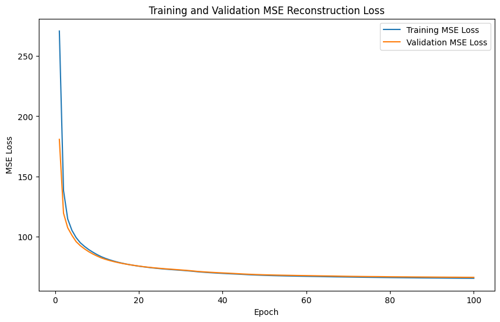

```python
import numpy as np

epochs = np.arange(1, len(history['training_loss']) + 1)
train_loss = np.array(history['training_loss'])
val_loss = np.array(history['validation_loss'])

plt.figure(figsize=(10, 6))
plt.plot(epochs, train_loss, label='Training MSE Loss')
plt.plot(epochs, val_loss, label='Validation MSE Loss')
plt.xlabel('Epoch')
plt.ylabel('MSE Loss')
plt.title('Training and Validation MSE Reconstruction Loss')
plt.legend()
plt.show()
```

The early stop is not triggered. Meanwhile, I find that the MSE Loss doesn't decay to the same value in each training process. I did some test like increase the epoch size to make it reaches the early stop, but the outcome can still not be the same. Sometimes MSE Loss will be 60 or 70, and sometimes it will stop at 140. I think there might has two reasons. 1: The training model has randomness, which leads to different outcome. 2: There exists different local minimisation. Because it is actually trying to solve a non-convex problem, which will lead it fall into local minimal trap. The initial direction might leads to different outcome.

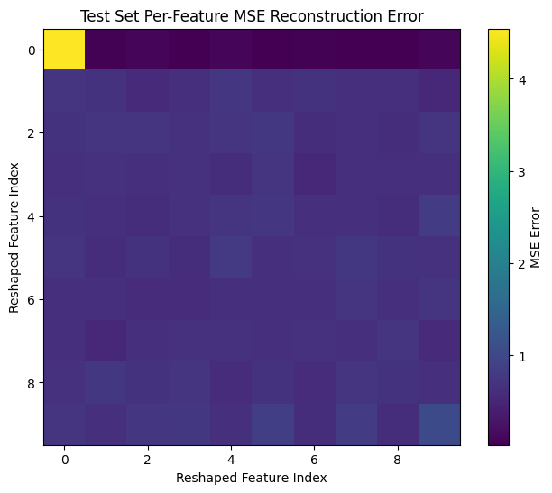

```python
import matplotlib.pyplot as plt
import torch

# Evaluate on the test set
model.eval()
all_inputs = []
all_outputs = []
with torch.no_grad():
    for inputs, _ in test_loader:
        if inputs.ndim == 3:
            inputs = inputs.unsqueeze(1)
        elif inputs.ndim == 4 and inputs.shape[1] != 1:
            inputs = inputs[:, :1, :, :]
        outputs = model(inputs)
        all_inputs.append(inputs)
        all_outputs.append(outputs)

# Concatenate all batches
all_inputs = torch.cat(all_inputs, dim=0)
all_outputs = torch.cat(all_outputs, dim=0)

# Flatten each sample: from (1, 10, 10) to (100,)
all_inputs_flat = all_inputs.view(all_inputs.size(0), -1)
all_outputs_flat = all_outputs.view(all_outputs.size(0), -1)


per_feature_mse = torch.mean((all_inputs_flat - all_outputs_flat) ** 2, dim=0).numpy()

# Reshape the resulting 100-length vector into a 10x10 grid
per_feature_mse_heatmap = per_feature_mse.reshape(10, 10)

# Plot the heatmap
plt.figure(figsize=(8, 6))
plt.imshow(per_feature_mse_heatmap, cmap='viridis', interpolation='nearest')
plt.title("Test Set Per-Feature MSE Reconstruction Error")
plt.xlabel("Reshaped Feature Index")
plt.ylabel("Reshaped Feature Index")
plt.colorbar(label="MSE Error")
plt.show()
```

The feature one not quite fit the model, which leads to greater affect towards MSE error, the feature from 2 to 10 fit the model the most. The other feature contributes almost the same contribution towards the MSE Loss

## (1.2) (index)

1.2(1)

The dimension of the output against encode is 8 * 5 * 5, show this again: For conv2d, the dimension of channel turns from 1 channel to 8, and for the 10*10 matrix. The size turn to (10 + 2 * padding -kernel_size) / stride + 1 = 10 + 2 - 3 + 1 = 10. The activation function ReLU won't change the dimension. And the max_pool turns the size to (10 - kernel_size) // stride + 1 = (10 -2) //2 + 1 =5. Thus, the output of the encode layer is 8 * 5 * 5.

Before we start, I will introduce the idea to solve this question: Firstly, we extract the encode model already trained from 1.1. Set it to .eval for following data extract. Secondly, extract the data from the test set, plot the graph of [0,0,0], [1,0,1]. Then, still use the data to get the batch_size * 8*5*5 dataset, use np.reshape as the flatten layer. Finally, define a new model just contains the linear layer, train this model to get the result.

```python
encode_model = model[0:5]
encode_model.eval()
```

```
Sequential(
  (0): Conv2d(1, 8, kernel_size=(3, 3), stride=(1, 1), padding=(1, 1))
  (1): ReLU()
  (2): MaxPool2d(kernel_size=(2, 2), stride=2, padding=0, dilation=1, ceil_mode=False)
  (3): Conv2d(8, 8, kernel_size=(3, 3), stride=(1, 1), padding=(1, 1))
  (4): ReLU()
)
```

```python
encode_model
```

```
Sequential(
  (0): Conv2d(1, 8, kernel_size=(3, 3), stride=(1, 1), padding=(1, 1))
  (1): ReLU()
  (2): MaxPool2d(kernel_size=(2, 2), stride=2, padding=0, dilation=1, ceil_mode=False)
  (3): Conv2d(8, 8, kernel_size=(3, 3), stride=(1, 1), padding=(1, 1))
  (4): ReLU()
)
```

```python
#Extract the dataset.
def extract_encoder_output(encoder, data_loader):
    encoded_outputs = []
    with torch.no_grad():
        for batch in data_loader:
            x = batch[0]
            if x.ndim==3:
                x = x.unsqueeze(1)
            encoded = encoder(x)
            encoded_flat = encoded.view(encoded.size(0), -1) #Flatten.
            encoded_outputs.append(encoded_flat.numpy())
    return np.vstack(encoded_outputs)
```

```python
X_train_encoded = extract_encoder_output(encode_model, train_loader)
X_test_encoded = extract_encoder_output(encode_model, test_loader)
X_val_encoded = extract_encoder_output(encode_model, val_loader)
```

```python
X_train_encoded_reshape = X_train_encoded.reshape(X_train_encoded.shape[0], -1)
X_test_encoded_reshape = X_test_encoded.reshape(X_test_encoded.shape[0], -1)
X_val_encoded_reshape = X_val_encoded.reshape(X_val_encoded.shape[0], -1)
```

```python
encoder_output_test = []

#test_loader = DataLoader(TensorDataset(X_test_tensor.unsqueeze(1), y_test_tensor), batch_size = batch_size, shuffle=False)
with torch.no_grad():
    for inputs in test_loader:
        x = inputs[0]
        if x.ndim==3:
            x = x.unsqueeze(1)
        encoded = encode_model(x)  # Forward pass
        encoder_output_test.append(encoded.numpy())

# Convert lists to NumPy arrays
encoder_output_test = np.vstack(encoder_output_test)  # Shape: (N, 8, 5, 5)
```

```python
x_vals = encoder_output_test[:, 1, 0, 1]
y_vals = encoder_output_test[:, 0, 0, 0]
```

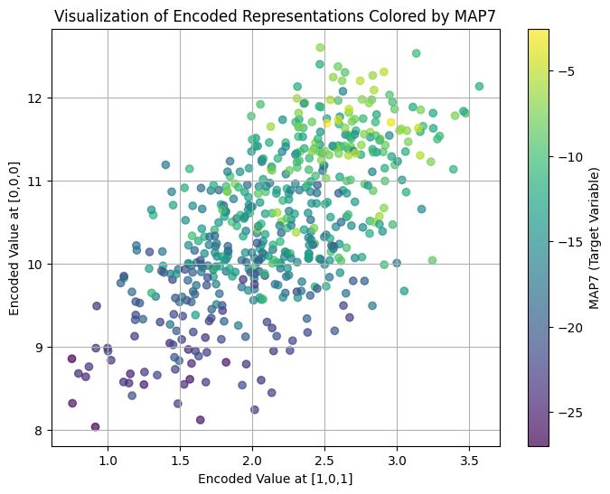

```python
plt.figure(figsize=(8, 6))
scatter = plt.scatter(x_vals, y_vals, c=y_test, cmap="viridis", alpha=0.7, marker="o")

# Add color legend
plt.colorbar(scatter, label="MAP7 (Target Variable)")

# Labels and title
plt.xlabel("Encoded Value at [1,0,1]")
plt.ylabel("Encoded Value at [0,0,0]")
plt.title("Visualization of Encoded Representations Colored by MAP7")
plt.grid(True)
```

For this graph, as I said in 1.1. Because of the local minimal trapping. It leads to different model and distribution. But no matter what the model is, we can find there has clustering in this distribution. The MAP7 larger value points will separate with those points have lower MAP7 value.

1.2(2)

```python
#Set the data back to dataLoader
```

```python
train_loader_tensor = DataLoader(TensorDataset(torch.tensor(X_train_encoded_reshape, dtype=torch.float32), y_train_tensor), batch_size, shuffle=False)
test_loader_tensor = DataLoader(TensorDataset(torch.tensor(X_test_encoded_reshape, dtype=torch.float32), y_test_tensor), batch_size, shuffle=False)
val_loader_tensor = DataLoader(TensorDataset(torch.tensor(X_val_encoded_reshape, dtype=torch.float32), y_val_tensor), batch_size, shuffle=False)
```

```python
def get_linear():
    model = nn.Sequential(
        nn.Linear(200, 1)
    )
    optimiser = optim.Adam(model.parameters(), lr=1e-3)
    return model, optimiser
```

```python
def r2_score(y_true, y_pred):
    y_true = np.array(y_true)
    y_pred = np.array(y_pred)
    ss_res = np.sum((y_true - y_pred)**2)
    ss_tot = np.sum((y_true - np.mean(y_true))**2)
    return 1 - ss_res / ss_tot if ss_tot != 0 else 0.0
```

```python
def mse_loss(y_true, y_pred):
    k = y_true.shape[0]
    return torch.mean((y_true.view(k, 1) - y_pred.view(k,1)) ** 2)
```

```python
linear_model, optimiser = get_linear()
```

```python
linear_model
```

```
Sequential(
  (0): Linear(in_features=200, out_features=1, bias=True)
)
```

The logic to compute the train_loop of the linear layer almost the same, just need to calculate the r2 against each epoch.

```python
def train_loop_linear(train_loader, val_loader, model, optimiser, max_num_epochs=1000, max_patience=10):
    history = {'training_loss': [], 'validation_loss': [], 'training_r2': [], 'validation_r2': []}
    early_stopping = EarlyStopping(max_patience=max_patience)

    # Define loss function and optimizer
    criterion = mse_loss
    for epoch in range(max_num_epochs):
        model.train()
        total_train_loss = 0.0
        train_preds_list = []
        train_targets_list = []
        for inputs, targets in train_loader:
            optimiser.zero_grad()
            outputs = model(inputs)        # Forward pass
            loss = criterion(outputs, targets)  # Compute MSE loss
            loss.backward()              # Backpropagation
            optimiser.step()             # Update parameters
            total_train_loss += loss.item() * inputs.size(0)
            train_preds_list.append(outputs.detach().numpy())
            train_targets_list.append(targets.detach().numpy())
        avg_train_loss = total_train_loss / len(train_loader.dataset)
        history['training_loss'].append(avg_train_loss)

        train_preds_all = np.concatenate(train_preds_list, axis=0)
        train_targets_all = np.concatenate(train_targets_list, axis=0)
        r2_train = r2_score(train_targets_all, train_preds_all)
        history['training_r2'].append(r2_train)


        model.eval()  # set to evaluation mode
        total_val_loss = 0.0
        val_preds_list = []
        val_targets_list = []
        with torch.no_grad():
            for inputs, targets in val_loader:
                outputs = model(inputs)
                loss = criterion(outputs, targets)
                total_val_loss += loss.item() * inputs.size(0)
                val_preds_list.append(outputs.numpy())
                val_targets_list.append(targets.numpy())
        avg_val_loss = total_val_loss / len(val_loader.dataset)
        history['validation_loss'].append(avg_val_loss)
        val_preds_all = np.concatenate(val_preds_list, axis=0)
        val_targets_all = np.concatenate(val_targets_list, axis=0)
        r2_val = r2_score(val_targets_all, val_preds_all)
        history['validation_r2'].append(r2_val)
        if epoch%10 == 0:
            print(f"Epoch {epoch+1}/{max_num_epochs}: Train Loss: {avg_train_loss:.4f}, Val Loss: {avg_val_loss:.4f}", f"Train R²: {r2_train:.4f}, Val R²: {r2_val:.4f}")

        # Early stopping check
        early_stopping.step(avg_val_loss)
        if early_stopping.early_stop:
            print(f"Early stopping triggered at epoch {epoch+1}.")
            break

    return history, model
```

```python
history, trained_linear_model = train_loop_linear(train_loader_tensor, val_loader_tensor, linear_model, optimiser, max_num_epochs=1000, max_patience=10)
```

```python
final_train_loss = history['training_loss'][999]
final_val_loss = history['validation_loss'][999]
r2_score = history['validation_r2'][999]
print(f'The final training loss is {final_train_loss :2f}')
print(f'The final validation loss is {final_val_loss :2f}')
print(f'The final r2 score of validation is {r2_score :2f}')
```

```
The final training loss is 7.493527
The final validation loss is 8.162162
The final r2 score of validation is 0.673046
```

The r2 score = 0.673 indicates that the model get a not bad prediction of the MAP7 prediction, meanwhile we observe that the training loss and the validation loss almost the same. So the overfitting problem not occured here.

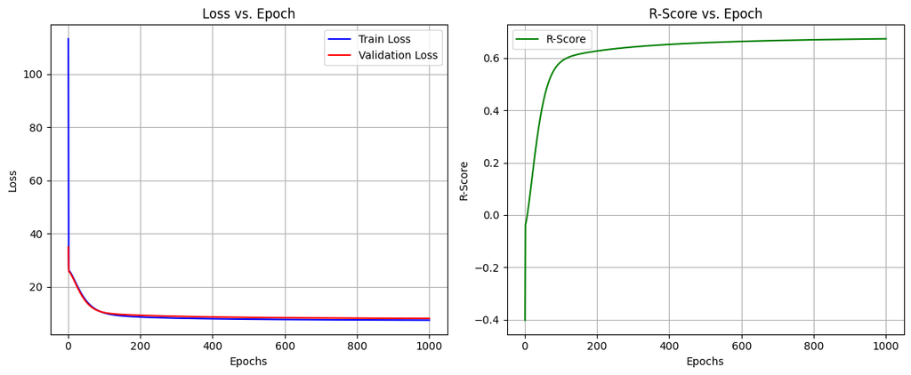

```python
epochs = range(1, len(history['training_loss']) + 1)

train_loss = history['training_loss']
val_loss = history['validation_loss']
r_score = history['validation_r2']


plt.figure(figsize=(12, 5))

plt.subplot(1, 2, 1)
plt.plot(epochs, train_loss, label="Train Loss", color='blue')
plt.plot(epochs, val_loss, label="Validation Loss", color='red')
plt.xlabel("Epochs")
plt.ylabel("Loss")
plt.title("Loss vs. Epoch")
plt.legend()
plt.grid(True)


plt.subplot(1, 2, 2)
plt.plot(epochs, r_score, label="R-Score", color='green')
plt.xlabel("Epochs")
plt.ylabel("R-Score")
plt.title("R-Score vs. Epoch")
plt.legend()
plt.grid(True)

plt.tight_layout()
plt.show()
```

# Task 2: Graph-based learning (index)

```python
PATH='' # Put your path to the file here

# Dataset upload #
import pandas as pd
import numpy as np
dataset = pd.read_csv(PATH + "gene_expression_transcriptomic_data.csv")

X = dataset.iloc[:400, :10].values # extract the first 400 rows and 10 columns
treatment = dataset.iloc[:, 101].values[:400, ] # extract the corresponding 400 treatment labels
```

```python
X.shape
```

```
(400, 10)
```

## (2.1) (index)

```python
#Get the similarity matrix as required
def cosine_similar_matrix(X):
    dot = np.dot(X, X.T)
    norms = np.linalg.norm(X, axis=1)
    norm_matrix = np.outer(norms, norms)
    S = dot / norm_matrix

    return S
```

```python
cos_m = cosine_similar_matrix(X) #Matrix required.
```

```python
#Get adjacency_matrix, set (i,j) to S if it is greater than threshold.
def thresholded_adjacency_matrix(S, delta):
    A = np.where((S >= delta) & (np.eye(S.shape[0]) == 0), S, 0)
    return A
```

```python
delta_values = np.linspace(np.min(cos_m), np.max(cos_m), 200) #Set the delta values as required.
```

```python
#Function to calculate the connected points by given A.
def connected_components(A):
    N = A.shape[0]
    visited = np.zeros(N, dtype=bool)
    labels = -np.ones(N, dtype=int)
    component = 0
    for i in range(N):
        if not visited[i]:
            # New connected component found; perform DFS starting from node i.
            stack = [i]
            while stack:
                node = stack.pop()
                if not visited[node]:
                    visited[node] = True
                    labels[node] = component
                    # Identify neighbors where there is an edge (A[node, j] > 0)
                    neighbors = np.where(A[node, :] > 0)[0]
                    # Add neighbors that haven't been visited yet.
                    for neigh in neighbors:
                        if not visited[neigh]:
                            stack.append(neigh)
            component += 1

    return component, labels
```

```python
connected_numbers = []
sparsity = []
for delta in delta_values:
    A_delta = thresholded_adjacency_matrix(cos_m, delta)
    components, _ = connected_components(A_delta)
    connected_numbers.append(components)
    edges = np.count_nonzero(A_delta)/2
    max_edges = 400 * 399 / 2 #It is the maximum possible edges possible.
    sparsity.append(edges/max_edges)
```

```python
delta_star = max(delta for delta, comp in zip(delta_values, connected_numbers) if comp == 1)
print("Largest threshold δ* keeping the graph connected:", delta_star)
```

```
Largest threshold δ* keeping the graph connected: 0.9990089178198224
```

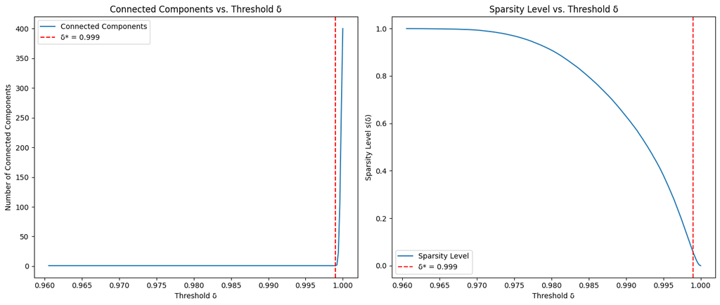

```python
plt.figure(figsize=(14, 6))


plt.subplot(1, 2, 1)
plt.plot(delta_values, connected_numbers, label='Connected Components')
plt.axvline(x=delta_star, color='red', linestyle='--', label=f'δ* = {delta_star:.3f}')
plt.xlabel('Threshold δ')
plt.ylabel('Number of Connected Components')
plt.title('Connected Components vs. Threshold δ')
plt.legend()

# Plot sparsity level vs. threshold δ
plt.subplot(1, 2, 2)
plt.plot(delta_values, sparsity, label='Sparsity Level')
plt.axvline(x=delta_star, color='red', linestyle='--', label=f'δ* = {delta_star:.3f}')
plt.xlabel('Threshold δ')
plt.ylabel('Sparsity Level s(δ)')
plt.title('Sparsity Level vs. Threshold δ')
plt.legend()

plt.tight_layout()
plt.show()
```

```python
A_best = thresholded_adjacency_matrix(cos_m, delta_star) #Matrix with delta_star
```

```python
#Do as the same in the lab.
D = np.diag(np.sum(A_best, axis=1))
L = D - A_best
```

```python
D_sqrt_inv = np.diag(1.0 / (np.sqrt(np.sum(A_best, axis=1))))
L_s = D_sqrt_inv @ L @ D_sqrt_inv
```

```python
e_val, e_vec = np.linalg.eigh(L_s)
eigenvecs = e_vec.T[np.argsort(e_val)]   # <-- SOLUTION
eigenvals = np.sort(e_val) #Store the e-values.
x_coor = eigenvecs[1] #Get the second and third smallest e-vals and relative e-vectors.
y_coor = eigenvecs[2]
```

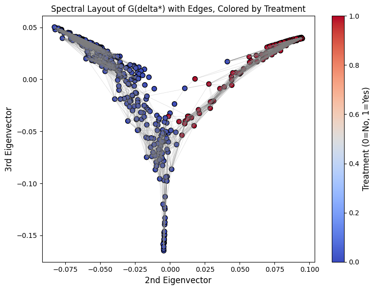

```
Sparsity of G(delta*): 0.0544
```

```python
fig, ax = plt.subplots(figsize=(8, 6))
for i in range(400):
    for j in range(i + 1, 400):
        if A_best[i, j] > 0:
            ax.plot([x_coor[i], x_coor[j]],
                    [y_coor[i], y_coor[j]],
                    color='gray', alpha=0.3, linewidth=0.5)
scatter = ax.scatter(x_coor, y_coor,
                     c=treatment, cmap='coolwarm',
                     edgecolor='k', s=50)
cbar = plt.colorbar(scatter, ax=ax)
cbar.set_label('Treatment (0=No, 1=Yes)', fontsize=12)

ax.set_xlabel('2nd Eigenvector', fontsize=12)
ax.set_ylabel('3rd Eigenvector', fontsize=12)
ax.set_title('Spectral Layout of G(delta*) with Edges, Colored by Treatment', fontsize=12)

plt.tight_layout()
plt.show()


# Compute sparsity
num_edges_final_task2 = np.count_nonzero(A_best) / 2
max_edges_task2 = 400 * 399 / 2
sparsity_final_task2 = num_edges_final_task2 / max_edges_task2

print(f"Sparsity of G(delta*): {sparsity_final_task2:.4f}")
```

```python
#We can find the sparsity of G(delta_star) can be very low, which indicates great separation between different treatment.
```

## (2.2) (index)

```python
total_edges = np.count_nonzero(A_best) / 2 #Calculate the non-zeros points and divide by two.
total_edges
```

```
4339.0
```

```python
degrees = np.sum(A_best > 0, axis=1) #Centrality = d / 2E
degree_centrality = degrees / (2*total_edges)
```

```python
degree_0 = degrees[treatment == 0]
degree_1 = degrees[treatment == 1]
```

```python
degree_centrality_0 = degree_centrality[treatment == 0]
degree_centrality_1 = degree_centrality[treatment == 1]
```

```python
mean_0 = np.mean(degree_0)
mean_1 = np.mean(degree_1)
print(f'The mean degree of treatment 0 is {mean_0:3f}, the mean degree of treatment 1 is {mean_1}')
```

```
The mean degree of treatment 0 is 16.096667, the mean degree of treatment 1 is 38.49
```

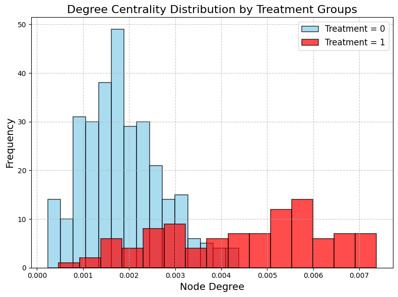

```python
plt.figure(figsize=(8, 6))
plt.hist(degree_centrality_0, bins=15, alpha=0.7, label='Treatment = 0',
         color='skyblue', edgecolor='black', linewidth=1.2)
plt.hist(degree_centrality_1, bins=15, alpha=0.7, label='Treatment = 1',
         color='red', edgecolor='black', linewidth=1.2)
plt.xlabel('Node Degree', fontsize=14)
plt.ylabel('Frequency', fontsize=14)
plt.title('Degree Centrality Distribution by Treatment Groups', fontsize=16)
plt.legend(fontsize=12)
plt.grid(True, linestyle='--', alpha=0.7)

plt.tight_layout()
plt.show()
```

```python
#The points with treatment0 separate more concentrated then the points with treatment1. The points with treatment1 connect to
#more points compare to treatment0.
```